# 01 Recap of visualization techniques in R

#### Pie Chart

A Pie Chart is a special chart that shows relative sizes of data using pie slices.

The syntax for the pie() function is:

pie(clockwise,init.angle,labels,density,angle,col,border,lty,main,…)

```r
#pie(airquality$Ozone)
```

```r
airquality <- na.omit(airquality)
```

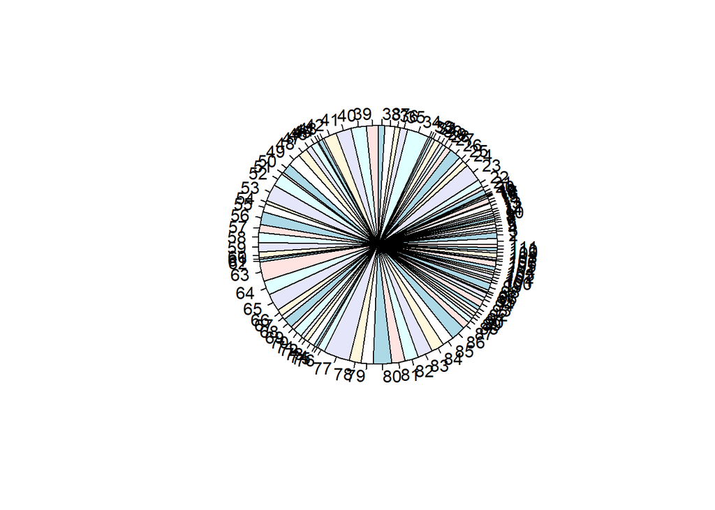

```r
pie(airquality$Ozone)
```

Does it make any sense?

So, here we will consider only the first 5 observations

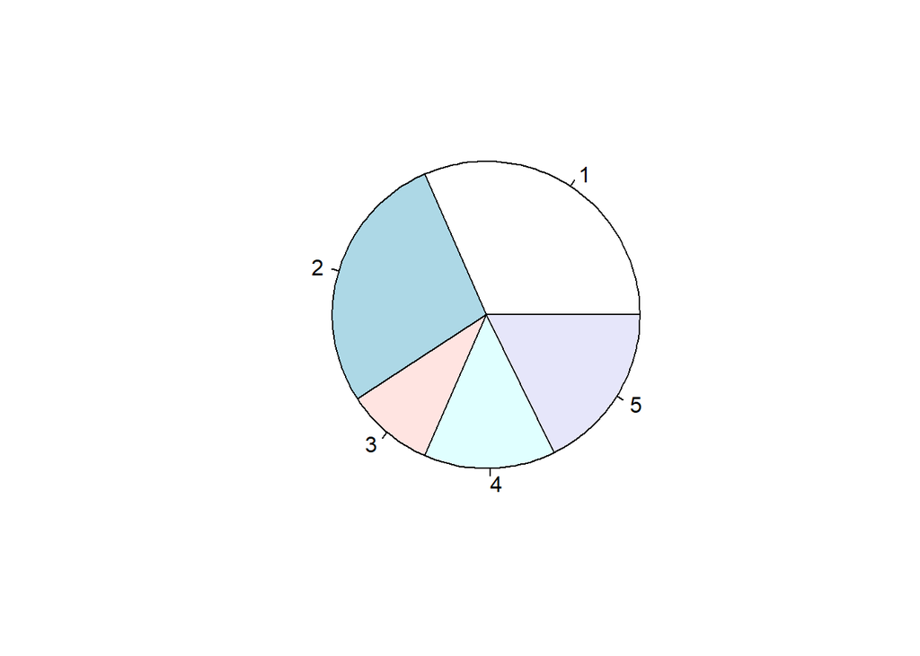

```r
pie(airquality$Ozone[1:5])
```

Now, we will label them with their actual values

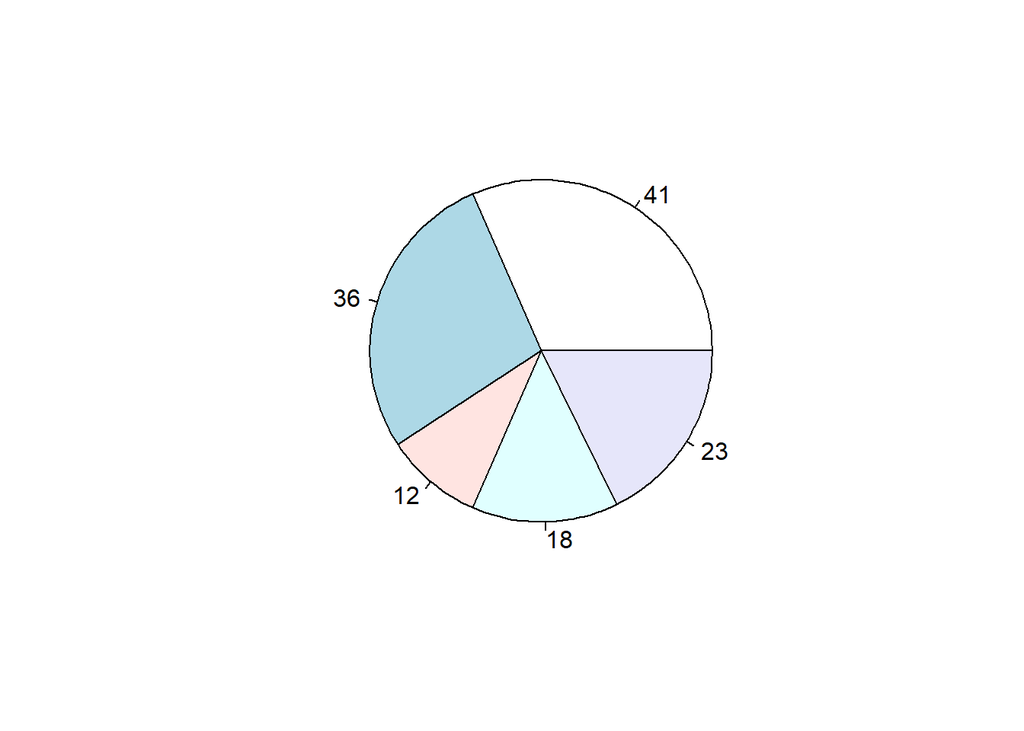

```r
pie(airquality$Ozone[1:5], labels = airquality$Ozone)
```

So, until this we have seen how to plot the simple graphic types using the base function.

### Some Important Base Graphics Parameters

Many base plotting functions share a set of global parameters. Here are a few key ones:

- pch: the plotting symbol (default is open circle)
- lty: the line type (default is solid line), can be dashed, dotted, etc.
- lwd: the line width, specified as an integer multiple
- col: the plotting color, specified as a number, string, or hex code; the colors() function gives you a vector of colors by name
- xlab: character string for the x-axis label
- ylab: character string for the y-axis label
- las: the orientation of the axis labels on the plot
- bg: the background color
- mar: the margin size
- oma: the outer margin size (default is 0 for all sides)
- mfrow: number of plots per row, column (plots are filled row-wise)
- mfcol: number of plots per row, column (plots are filled column-wise)

You can see the default values for global graphics parameters by calling the par() function and passing the name of the parameter in quotes.

```r
par("lty")
```

```
## [1] "solid"
```

```r
par("col")
```

```
## [1] "black"
```

```r
par("pch")
```

```
## [1] 1
```

Here are some more default values for global graphics parameters.

```r
par("bg")
```

```
## [1] "white"
```

```r
par("mar")
```

```
## [1] 5.1 4.1 4.1 2.1
```

```r
par("mfrow")
```

```
## [1] 1 1
```

For the most part, you usually don’t have to modify these when making quick plots. However, you might need to tweak them for finalizing finished plots.

### Base Plotting Function

The most basic base plotting function is plot(). The plot() function makes a scatterplot, or other type of plot depending on the class of the object being plotted. Calling plot() will draw a plot on the screen device (and open the screen device if not already open). After that, annotation functions can be called to add to the already-made plot.

For instance, the following will create a scatter plot

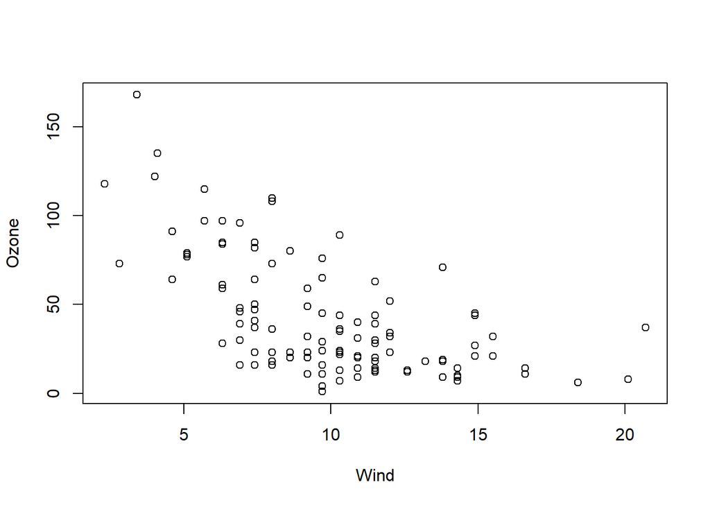

```r
## Make the initial plot
with(airquality, plot(Wind, Ozone))
```

Now, how about if you just change one variable to categorical (i.e., replace ‘Wind’ with ‘Month’)? What kind of plot do you think it will generate?

```r
with(airquality, plot(factor(Month), Ozone))
```

[output not shown]

Some key annotation functions are

- lines: add lines to a plot, given a vector of x values and a corresponding vector of y values (or a 2-column matrix); this function just connects the dots
- points: add points to a plot
- text: add text labels to a plot using specified x, y coordinates
- title: add annotations to x, y axis labels, title, subtitle, outer margin
- mtext: add arbitrary text to the margins (inner or outer) of the plot
- axis: adding axis ticks/labels

Here’s an example of creating a base plot and the adding some annotation. First we make the plot with the plot() function and then add a title to the top of the plot with the title() function.

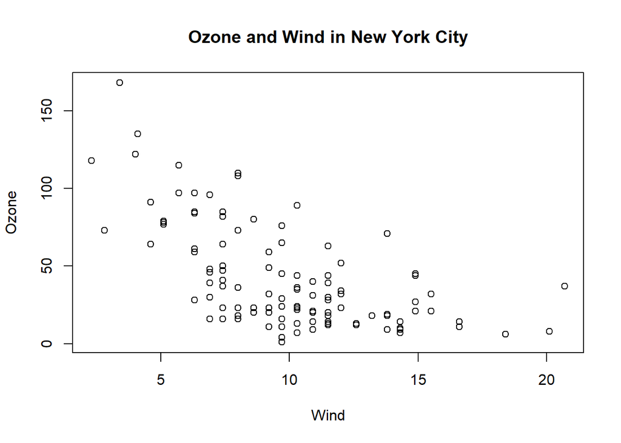

```r
library(datasets)
## Make the initial plot
with(airquality, plot(Wind, Ozone))
## Add a title
title(main = "Ozone and Wind in New York City")
```

Here, I start with the same plot as above (although I add the title right away using the main argument to plot()) and then annotate it by coloring blue the data points corresponding to the month of May.

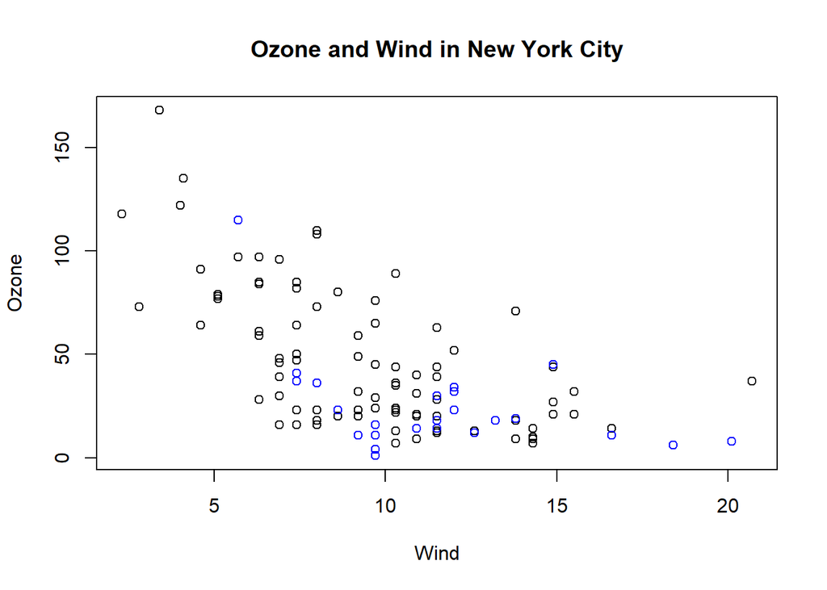

```r
with(airquality, plot(Wind, Ozone, main = "Ozone and Wind in New York City"))
with(subset(airquality, Month == 5), points(Wind, Ozone, col = "blue"))
```

The following plot colors the data points for the month of May blue and colors all of the other points red.

Notice that when constructing the initial plot, we use the option type = “n” in the call to plot(). This is a common paradigm as plot() will draw everything in the plot except for the data points inside the plot window. Then you can use annotation functions like points() to add data points. So here, we create the plot without drawing the data points, then add the blue points and then add the red points. Finally, we add a legend with the legend() function explaining the meaning of the different colors in the plot.

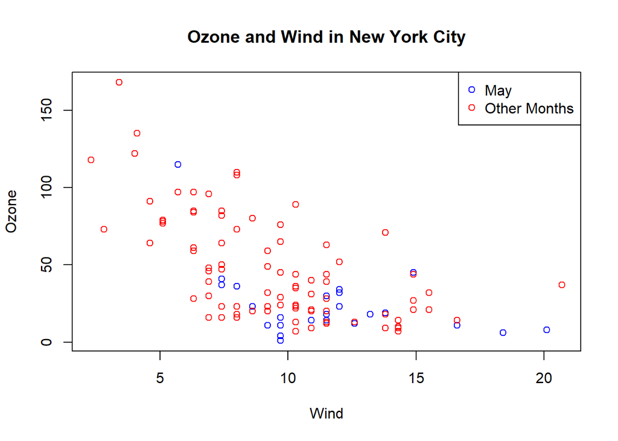

```r
with(airquality, plot(Wind, Ozone, main = "Ozone and Wind in New York City", type = "n"))

with(subset(airquality, Month == 5), points(Wind, Ozone, col = "blue"))

with(subset(airquality, Month != 5), points(Wind, Ozone, col = "red"))

legend("topright", pch = 1, col = c("blue", "red"), legend = c("May", "Other Months"))
```

#### Base Plot with Regression Line

It’s fairly common to make a scatterplot and then want to draw a simple linear regression line through the data. This can be done with the *abline()* function.

Below, we first make the plot (as above). Then we fit a simple linear regression model using the *lm()* function. Here, we try to model Ozone as a function of Wind. Then we take the output of *lm()* and pass it to the *abline()* function which automatically takes the information from the model object and calculates the corresponding regression line.

Note that in the call to *plot()* below, we set *pch = 20* to change the plotting symbol to a filled circle.

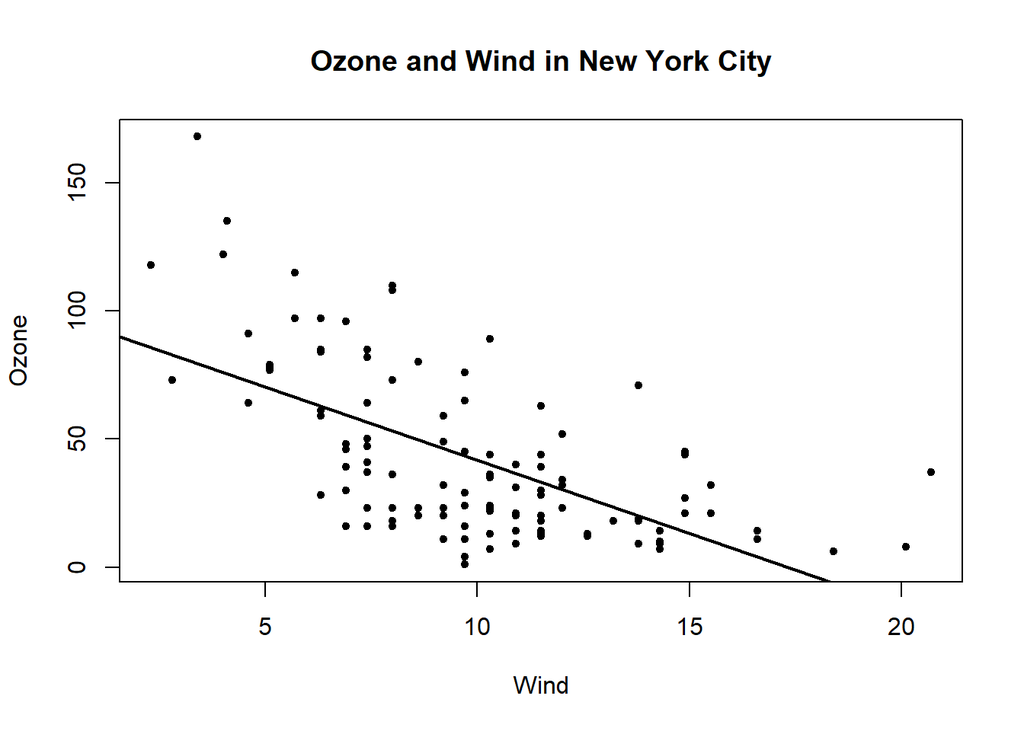

```r
with(airquality, plot(Wind, Ozone, main = "Ozone and Wind in New York City", pch = 20))
## Fit a simple linear regression model
model <- lm(Ozone ~ Wind, airquality)
## Draw regression line on plot
abline(model, lwd = 2)
```

#### Multiple Base Plots

Making multiple plots side by side is a useful way to visualize many relationships between variables with static 2-D plots. Often the repetition of data across a single plot window can be a useful way to identify patterns in the data. In order to do this, the **mfrow** and **mfcol** parameters set by the *par()* function are critical.

Both the **mfrow** and **mfcol** parameters take two numbers: the number of rows of plots followed by the number of columns. The multiple plots will be arranged in a matrix-like pattern. The only difference between the two parameters is that if **mfrow** is set, then the plots will be drawn row-wise; if **mfcol** is set, the plots will be drawn column-wise.

In the example below, we make two plots: one of Ozone and Wind and another with Ozone and Solar.R. We set *par(mfrow = c(1, 2))*, which indicates that we have one row of plots and two columns of plots.

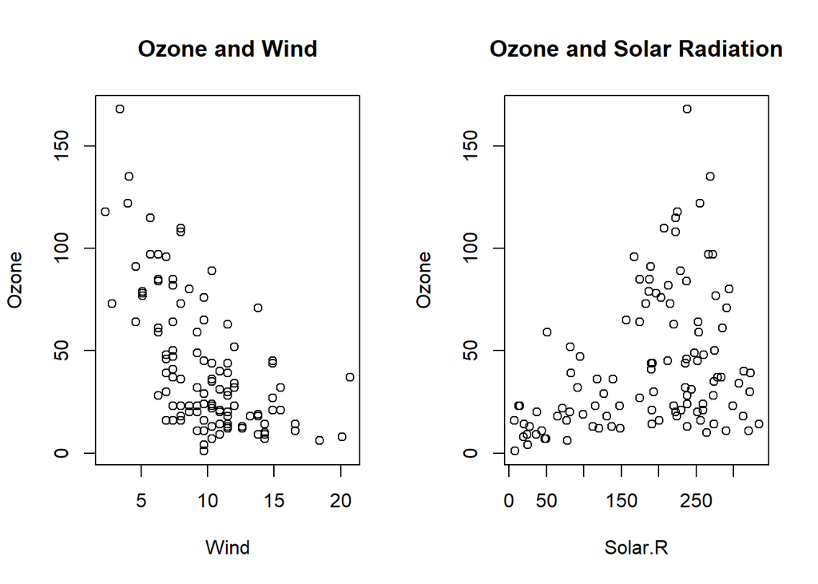

```r
par(mfrow = c(1, 2))
with(airquality, {
plot(Wind, Ozone, main = "Ozone and Wind")
plot(Solar.R, Ozone, main = "Ozone and Solar Radiation")
})
```

The example below creates three plots in a row by setting par(mfrow = c(1, 3)). Here we also change the plot margins with the mar parameter. The various margin parameters, like mar, are specified by setting a value for each side of the plot. Side 1 is the bottom of the plot, side 2 is the left hand side, side 3 is the top, and side 4 is the right hand side. In the example below we also modify the outer margin via the oma parameter to create a little more space for the plots and to place them closer together.

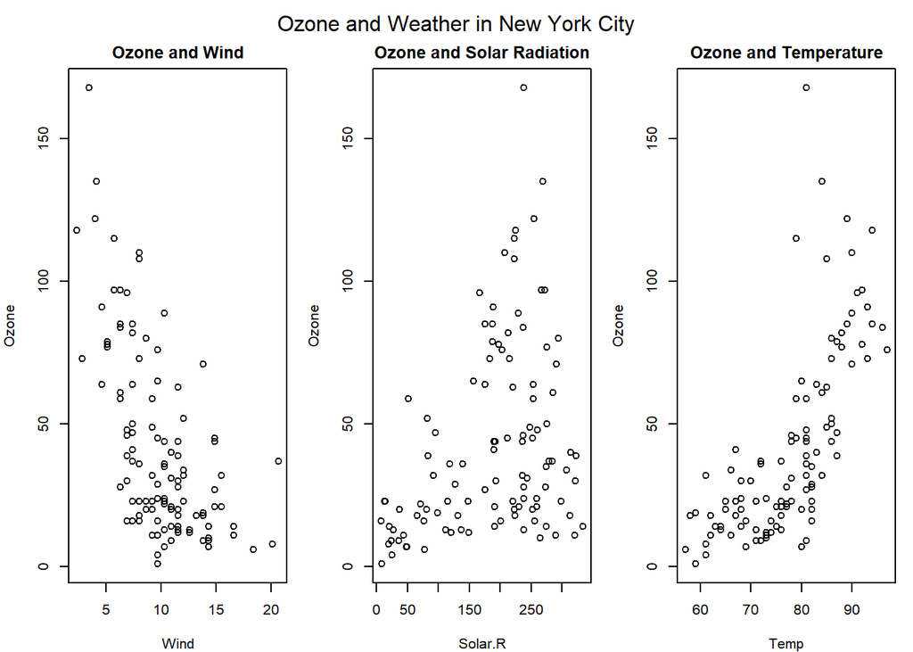

```r
par(mfrow = c(1, 3), mar = c(4, 4, 2, 1), oma = c(0, 0, 2, 0))
with(airquality, {
plot(Wind, Ozone, main = "Ozone and Wind")
plot(Solar.R, Ozone, main = "Ozone and Solar Radiation")
plot(Temp, Ozone, main = "Ozone and Temperature")
mtext("Ozone and Weather in New York City", outer = TRUE)
})
```

Or, we can also create the same plot this way as well

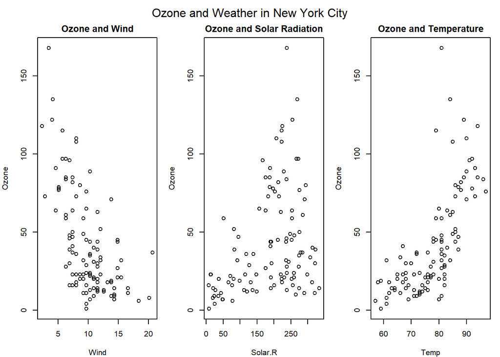

```r
par(mfrow = c(1, 3), mar = c(4, 4, 2, 1), oma = c(0, 0, 2, 0))
plot(airquality$Wind, airquality$Ozone, main = "Ozone and Wind", xlab = "Wind", ylab = "Ozone")
plot(airquality$Solar.R, airquality$Ozone, main = "Ozone and Solar Radiation", xlab = "Solar.R", ylab = "Ozone")
plot(airquality$Temp, airquality$Ozone, main = "Ozone and Temperature", xlab = "Temp", ylab = "Ozone")
mtext("Ozone and Weather in New York City", outer = TRUE)
```

In the above example, the mtext() function was used to create an overall title for the panel of plots. Hence, each individual plot has a title, while the overall set of plots also has a summary title. The mtext() function is important for adding text annotations that aren’t specific to a single plot.

#### **Optional**

Before we close, let’s create the same scatter plot with a different pch type.

Now create a variable called may by subsetting airquality appropriately. (Recall that the data specifies months by number and May is the fifth month of the year.)

```r
may <- subset(airquality, Month == 5)
#may
```

Now use the R command points to plot May’s wind and ozone (in that order) as solid blue triangles. You have to set the color and plot character with two separate arguments. Note we use points because we’re adding to an existing plot.

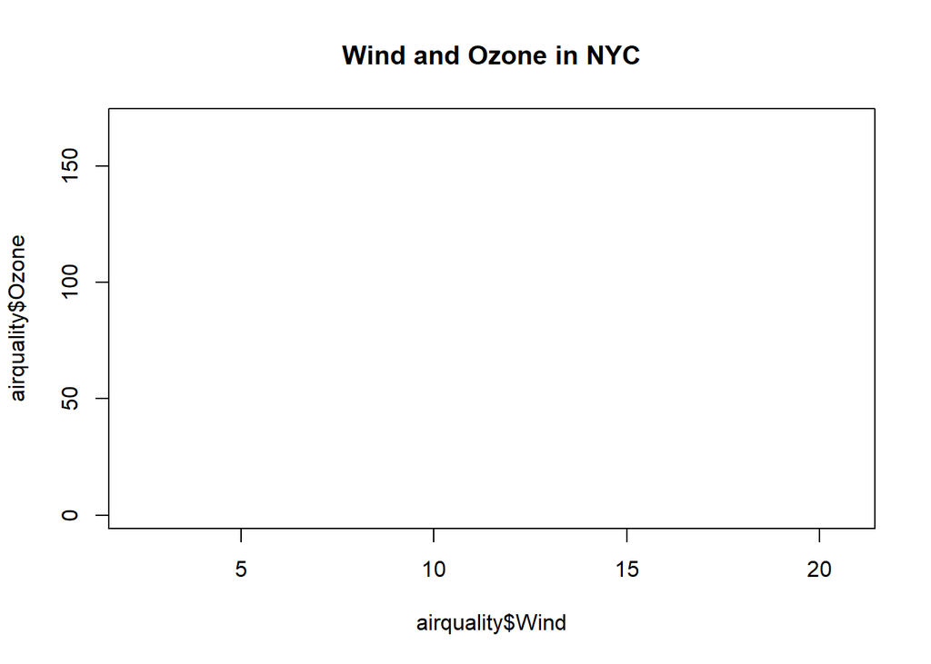

```r
plot(airquality$Wind, airquality$Ozone, type = "n")
title(main = "Wind and Ozone in NYC")
```

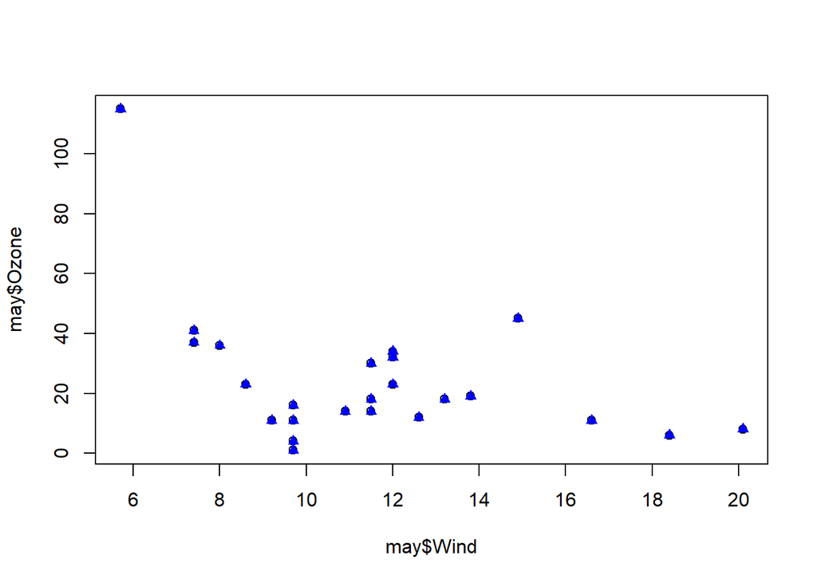

```r
plot(may$Wind, may$Ozone)
points(may$Wind, may$Ozone, col="blue",pch=17)
```

Now create the variable notmay by subsetting airquality appropriately.

```r
notmay <- subset(airquality, Month != 5)
#notmay
```

Now use the R command points to plot these notmay’s wind and ozone (in that order) as red snowflakes.

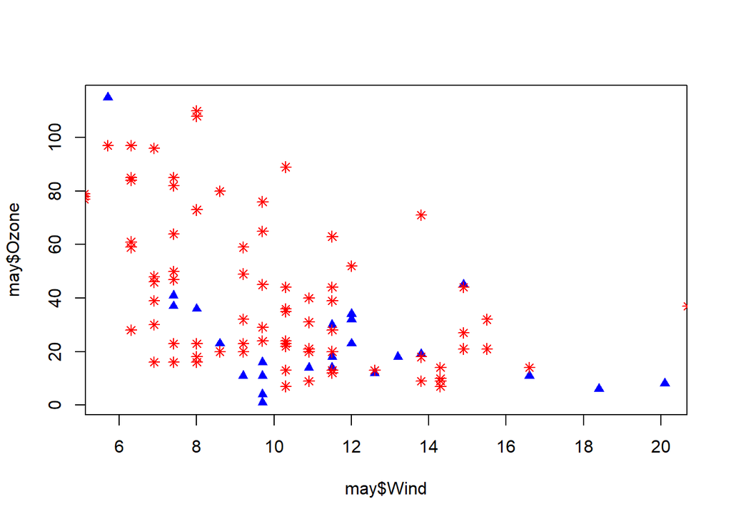

```r
plot(may$Wind, may$Ozone, col="blue",pch=17)
points(notmay$Wind, notmay$Ozone, col = "red", pch = 8)
```

Now we’ll use the R command legend to clarify the plot and explain what it means. The function has a lot of arguments, but we’ll only use 4. The first will be the string “topright” to tell R where to put the legend. The remaining 3 arguments will each be 2-long vectors created by R’s concatenate function, e.g., c(). These arguments are pch, col, and legend. The first is the vector (17,8), the second (“blue”,“red”), and the third (“May”,“Other Months”). Try it now.

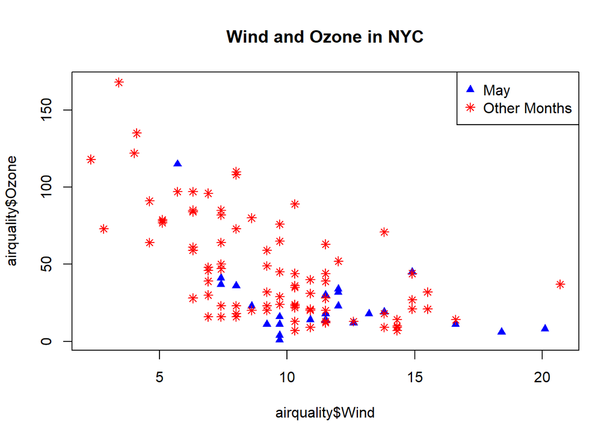

```r
plot(airquality$Wind, airquality$Ozone, type = "n")
title(main = "Wind and Ozone in NYC")

points(may$Wind, may$Ozone, col="blue",pch=17)
notmay <- subset(airquality, Month != 5)
points(notmay$Wind, notmay$Ozone, col = "red", pch = 8)

legend("topright", pch = c(17, 8), col = c("blue", "red"), legend = c("May", "Other Months"))
```

Now add a vertical line at the median of airquality$Wind. Make it dashed (lty=2) with a width of 2.

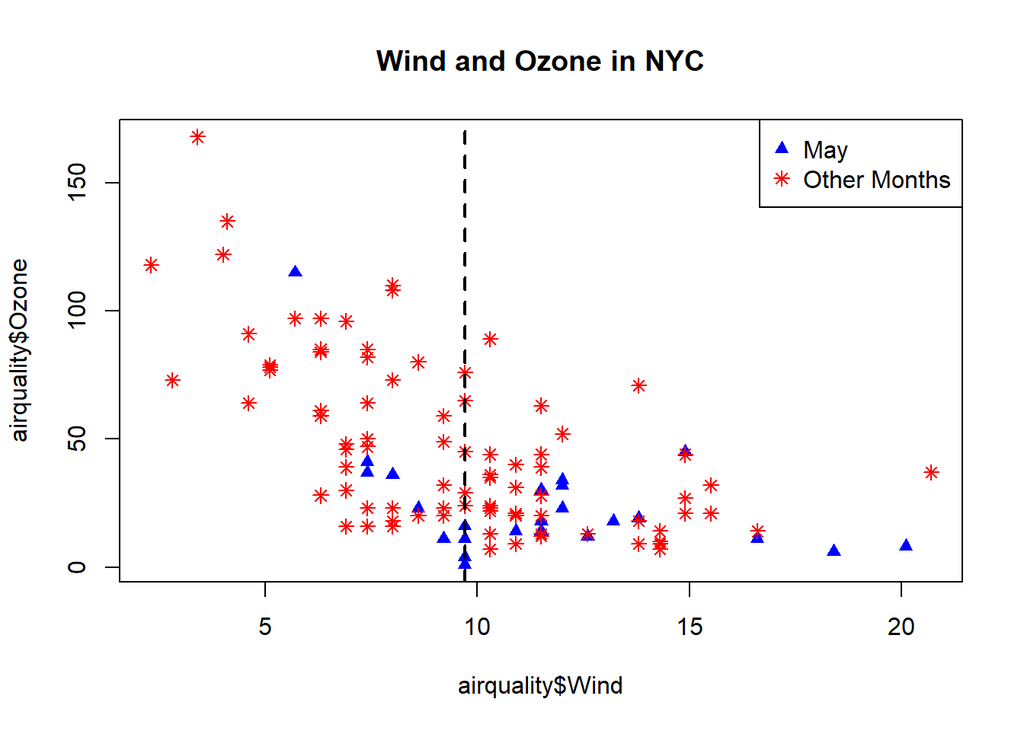

```r
plot(airquality$Wind, airquality$Ozone, type = "n")
title(main = "Wind and Ozone in NYC")

points(may$Wind, may$Ozone, col="blue",pch=17)
notmay <- subset(airquality, Month != 5)
points(notmay$Wind, notmay$Ozone, col = "red", pch = 8)

legend("topright", pch = c(17, 8), col = c("blue", "red"), legend = c("May", "Other Months"))

abline(v = median(airquality$Wind), lty=2, lwd=2)
```

```r
rm(list=ls())
```

## Lattice

The typical format used to plot lattice graphs is: graph_type(formula, data=)

Such that,

- graph_type: represents the type of graph to represent.
- formula: specifies the variables or conditioned variables.

Now we will try to create the above plots using lattice

```r
library(datasets)
library(lattice)
```

#### Available Functions in the Lattice Package

There are several functions available in the Lattice package that can be deployed for several purposes. Some of the most common functions used are the following:

- xyplot()
- splom()
- cloud()
- stripplot()
- bwplot()
- dotplot()
- barchart()
- histogram()
- densityplot
- qqmath()
- qq()

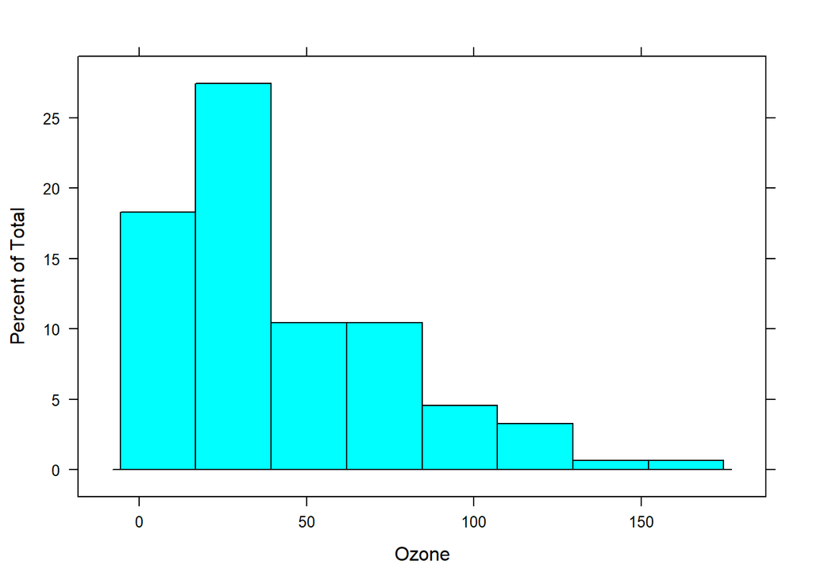

```r
#histogram
histogram(~ Ozone, data = airquality)
```

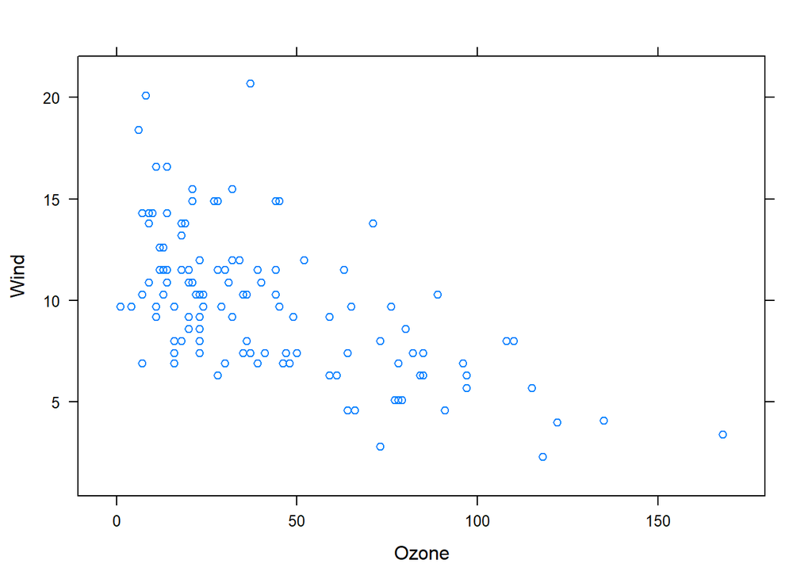

```r
#scatter_plot
xyplot(Wind~Ozone, airquality)
```

We can change the graph type, add title, and change the axes labels as well (basically customizing the plot) under all lattice functions. See the code as well as output graphical representation below for your reference:

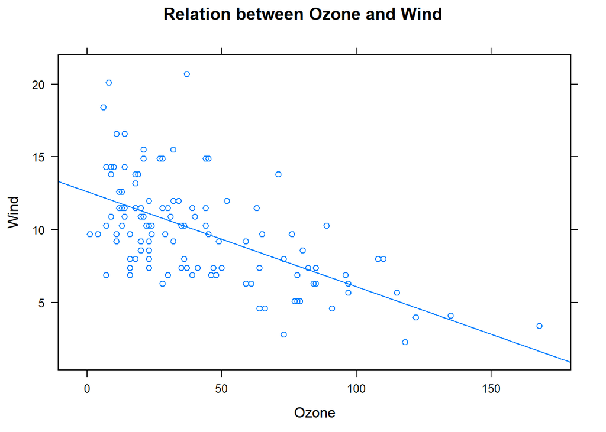

```r
#xy Scatter plot with customization

xyplot(Wind~Ozone,
         data = airquality,
         type = c("p", "r"),
         main = "Relation between Ozone and Wind",
         xlab = "Ozone",
         ylab = "Wind")
```

We can create a multivariate scatter plot visual as well (lattice is well known for it’s way of creating beautiful multivariate visualizations) and same could be seen below:

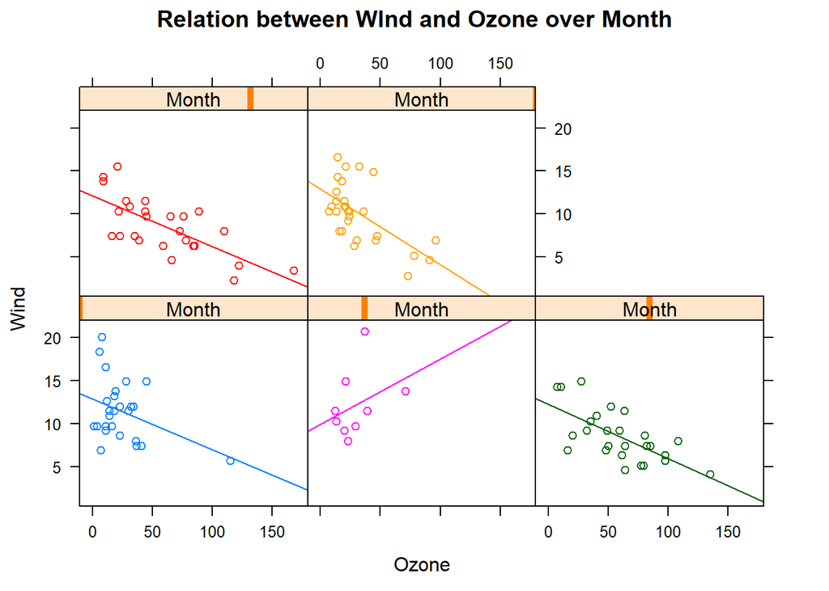

```r
#Multivariate xy scatter plot with customizations
xyplot(Wind~Ozone | Month,
         data = airquality,
         type = c("p", "r"),
         groups = Month,
         main = "Relation between WInd and Ozone over Month",
         xlab = "Ozone",
         ylab = "Wind")
```

Do you know why it’s not showing the months in the panels?

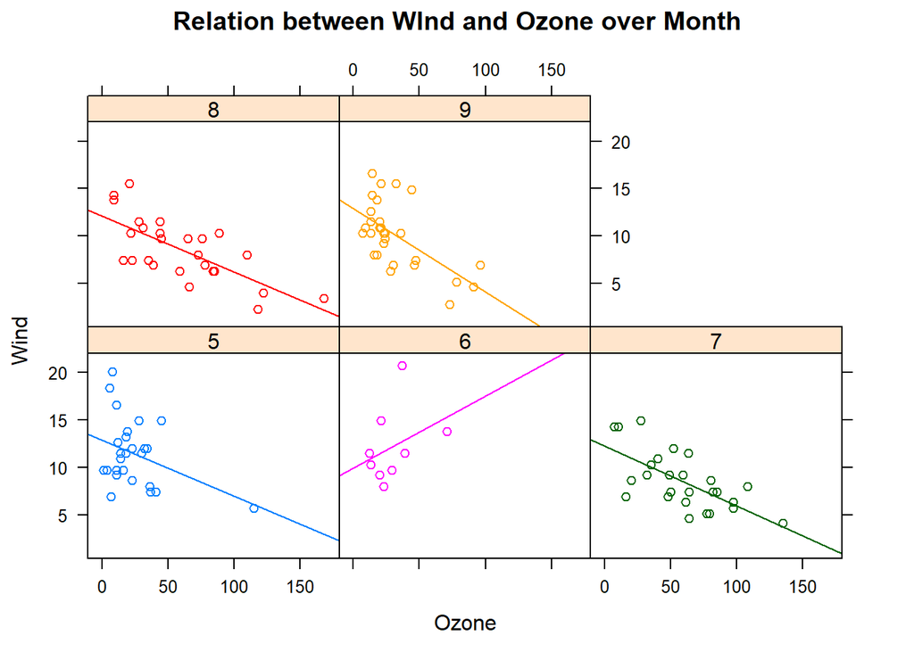

```r
airquality <- transform(airquality, Month = factor(Month))
xyplot(Wind~Ozone | Month,
       data = airquality,
       type = c("p", "r"),
       groups = Month,
       main = "Relation between WInd and Ozone over Month",
       xlab = "Ozone",
       ylab = "Wind")
```

Can you restrict the plot to a single row?

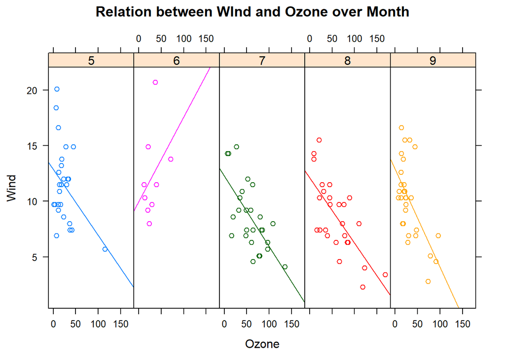

```r
xyplot(Wind~Ozone | Month,
       data = airquality,
       layout = c(5,1),
       type = c("p", "r"),
       groups = Month,
       main = "Relation between WInd and Ozone over Month",
       xlab = "Ozone",
       ylab = "Wind")
```

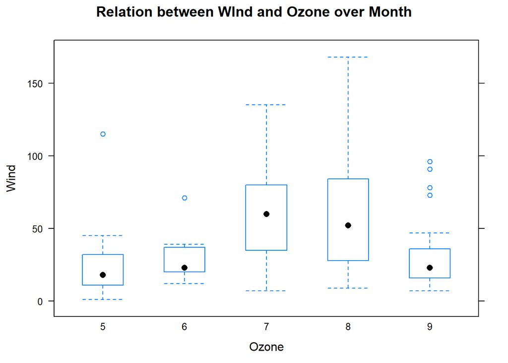

```r
## Box plot in lattice
#Syntax: bwplot(x, data, main = )
bwplot(Ozone~Month,
       data = airquality,
       #type = c("p", "r"),
       groups = Month,
       main = "Relation between WInd and Ozone over Month",
       xlab = "Ozone",
       ylab = "Wind")
```

## Exercises

Note: Use the same airquality dataset for the following exercises.

1. Plot a histogram to show the distribution of temperature of the airquality dataset.
2. Plot the relationship between Temperature and Solar radiation (scatterplot), and draw a regression line by fitting a simple linear regression model.
3. Can you produce the following plot? (hint: the colors are green, blue, orange and red)

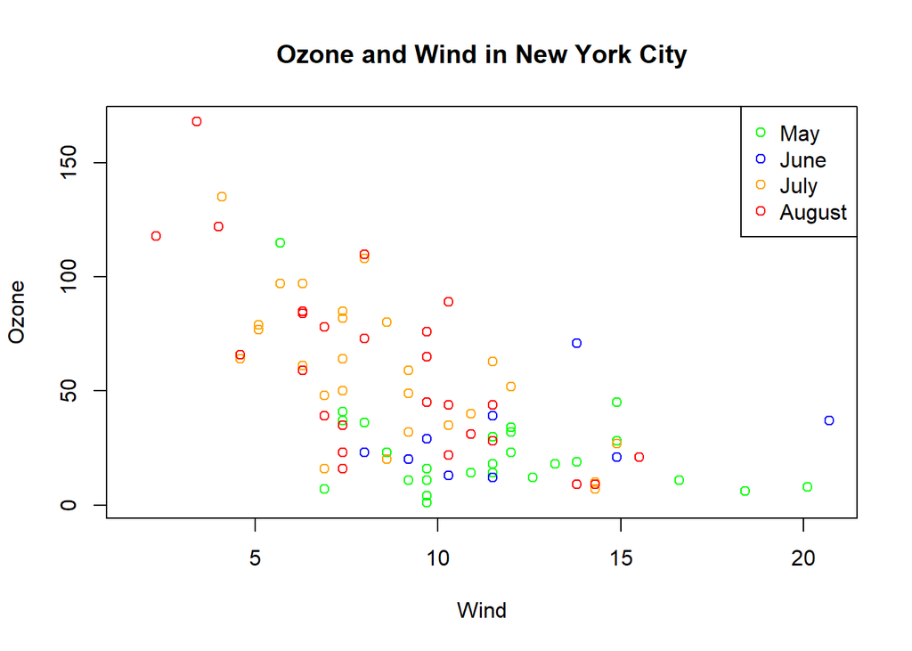

4. Can you write a script to produce the following plot? (hint: use pch = 4)

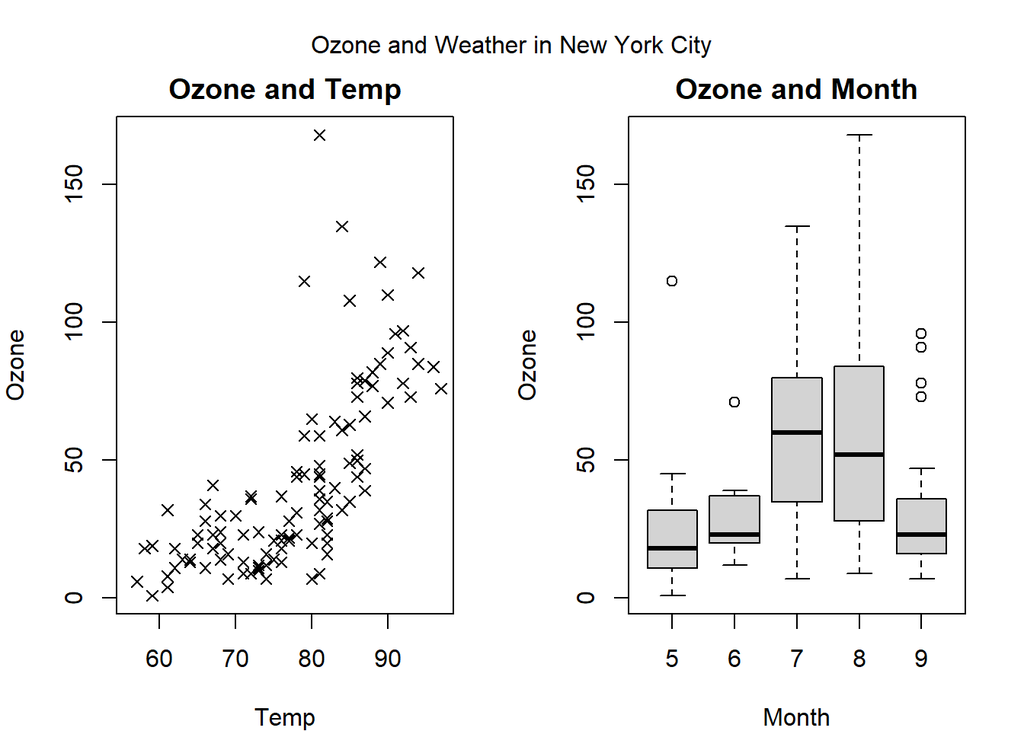